# Survival Analysis of the OPTN/UNOS Data

Fan Wu

June 01, 2016

# Contents

- Variable Used in the UNOS Datasets
- Brief Summary of the Data
- Diabetes Types as a Risk Factor
- Time-Varying Coefficient for Diabetes Types
- Interaction between Time on Dialysis and Diabetes

## Variable Used in the UNOS Datasets

| VARIABLE NAME | DESCRIPTION |
| --- | --- |
| `AGE` | RECIPIENT AGE (YRS) |
| `AGE_DON` | DONOR AGE (YRS) |
| `BMI_CALC` | Calculated Recipient BMI |
| `BMI_DON_CALC` | Donor BMI - Pre/At Donation Calculated |
| `COLD_ISCH_KI` | KIDNEY COLD ISCHEMIC TIME (HOURS) |
| `COMPOSITE_DEATH_DATE` | **Composite Patient Death Date from OPTN or Verified from External Sources** |
| `DAYSWAIT_CHRON` | TOTAL DAYS ON WAITING LIST INCLUDING INACTIVE TIME |
| `DIAB` | RECIPIENT DIABETES @ REGISTRATION |
| `DIAL_DATE` | **RECIPIENT DATE FIRST DIALYZED @ TRANSPLANT** |
| `DIAL_TRR` | RECIPIENT PRETRANSPLANT DIALYSIS (Y,N) @ TRANSPLANT |
| `DIALYSIS_DATE` | **WL Date of Initiation of Regularly Administered Dialysis for ESRD** |
| `DON_TY` | DONOR TYPE - DECEASED OR LIVING |
| `END_CPRA` | CANDIDATE MOST RECENT CALCULATED PRA |
| `ETHCAT` | RECIPIENT ETHNICITY CATEGORY |
| `ETHCAT_DON` | DONOR ETHNICITY CATEGORY |
| `FAILDATE_KI` | **GRAFT FAIL DATE-KIDNEY** |
| `GENDER` | RECIPIENT GENDER |
| `GENDER_DON` | DONOR GENDER |
| `HLAMIS` | HLA MISMATCH LEVEL |
| `INIT_DATE` | **DATE PLACED ON WAITING LIST** |
| `KDPI` | KDPI (Kidney Donor Profile Index) (ref. population = 2013) : Post 04/01/1994 |
| `PERIP_VASC` | RECIPIENT PERIPHERAL VASCULAR DISEASE @ REGISTRATION |
| `PT_CODE` | ENCRYPTED RECIPIENT IDENTIFIER |
| `PX_STAT` | Recipient Status at Time of Follow-Up(Died, ReTX, Lost, Not Seen, Alive) |
| `PX_STAT_DATE` | **Recipient Status Date at Time of Follow-Up** |
| `RETXDATE_KI` | Date of Retransplant |
| `TRR_ID_CODE` | ENCRYPTED TRANSPLANT IDENTIFIER |
| `TX_CTR` | Transplant Center |
| `TX_DATE` | **TRANSPLANT DATE** |

TOC

## Summary of the Data

KDPI is categorized (KDPIC) as 0-10%, 10-90%, 90+%, Missing or Living Donor (NOTE: since only *deceased donor* will have KDPI, we include donor type as another category in this variable; [there is a recent published paper on LKDPI](http://onlinelibrary.wiley.com/doi/10.1111/ajt.13709/abstract)), we did not include other donor characteristics from last time (age, gender, BMI etc.).

Frequency tables for all the categorized variables are given below.

```
## ----- AGEC -----
##
##  [18,35)  [35,50)  [50,60)  [60,75) [75,100)
##    12843    26175    26250    28618     1799
##
## ----- DON_TY -----
##
##     C     L
## 61755 33930
##
## ----- GENDER -----
##
##     F     M
## 37344 58341
##
## ----- ETHCAT -----
##
##    White    Black Hispanic    Asian    Other
##    50137    24503    14064     5403     1578
##
## ----- END_CPRA -----
##
##   [0,90) [90,100)  Missing
##    86225     5143     4317
##
## ----- HLAMIS -----
##
##     0     1     2     3     4     5     6
##  7866  2298  7577 16571 21619 25923 13096
##
## ----- DIAB -----
##
## No Diab  Type I Type II  Type U    Miss
##   63146    5105   24163    2413     858
##
## ----- PERIP_VASC -----
##
##           No          Yes Unknown/Miss
##        88828         4312         2545
##
```

[output cut: 9 more lines]

```
##
## ----- TDIALC -----
##
##       Miss Preemptive        0-2         2+
##        892      16859      27705      50229
##
## ----- KDPIC -----
##
##    LD  Miss  0-10 10-90   90+
## 33930   565  5559 51187  4444
##
## ----- CIT -----
##
##   [0,6) [18,30)  [6,18) Missing
##   30057   20143   33161   12324
```

TOC

## Diabetes Types as a Risk Factor

The `DIAB` in the data are coded as follows:

- 1: No diabetes;
- 2: Type I diabetes;
- 3: Type II diabetes;
- 4: Unknown Type;
- 5: Missing and Not Reported.

We then fit a stratified Cox model including all the risk factor and using TX centers as the strata:

- Recipient: Age, race, sex, BMI, sensitization status (using cPRA), diabetes, peripheral vascular disease
- Donor: KDPIC
- Transplantation: cold ischemia time, HLA mismatch ( 0-2,3-4, 5-6)

Separate models are fitted for graft (`T.GRF`) and patient (`T.PT`).

```
## Call:
## coxph(formula = Surv(T.GRF, D.GRF) ~ AGEC + GENDER + ETHCAT +
##     DIAB + PERIP_VASC + BMI + KDPIC + END_CPRA + CIT + HLAMISM +
##     strata(TX_CTR), data = unos)
##
##   n= 95685, number of events= 18202
##
##                             coef exp(coef)  se(coef)       z Pr(>|z|)
## AGEC[35,50)            -0.359094  0.698309  0.027512 -13.052  < 2e-16 ***
## AGEC[50,60)            -0.238885  0.787505  0.027375  -8.726  < 2e-16 ***
## AGEC[60,75)             0.027053  1.027423  0.027117   0.998 0.318443
## AGEC[75,100)            0.378235  1.459706  0.048951   7.727 1.10e-14 ***
## GENDERM                 0.080753  1.084103  0.015806   5.109 3.24e-07 ***
## ETHCATBlack             0.144649  1.155634  0.019137   7.558 4.09e-14 ***
## ETHCATHispanic         -0.231870  0.793049  0.027700  -8.371  < 2e-16 ***
## ETHCATAsian            -0.387297  0.678890  0.041277  -9.383  < 2e-16 ***
## ETHCATOther             0.029281  1.029714  0.060620   0.483 0.629075
## DIABType I              0.263347  1.301279  0.032943   7.994 1.33e-15 ***
## DIABType II             0.278250  1.320816  0.018428  15.100  < 2e-16 ***
## DIABType U              0.260972  1.298192  0.042423   6.152 7.67e-10 ***
## DIABMiss               -0.051089  0.950195  0.083691  -0.610 0.541570
## PERIP_VASCYes           0.333598  1.395981  0.031830  10.481  < 2e-16 ***
## PERIP_VASCUnknown/Miss  0.161503  1.175276  0.048355   3.340 0.000838 ***
## BMIUnderweight          0.122285  1.130076  0.055994   2.184 0.028970 *
## BMIOverweight          -0.006617  0.993405  0.019630  -0.337 0.736050
## BMIObese                0.081222  1.084612  0.019664   4.130 3.62e-05 ***
## BMIMissing              0.019558  1.019751  0.148511   0.132 0.895225
## KDPICMiss               0.784579  2.191484  0.085572   9.169  < 2e-16 ***
## KDPIC0-10               0.316966  1.372956  0.045070   7.033 2.03e-12 ***
## KDPIC10-90              0.592764  1.808981  0.031741  18.675  < 2e-16 ***
## KDPIC90+                1.050767  2.859844  0.040035  26.246  < 2e-16 ***
## END_CPRA[90,100)        0.217384  1.242822  0.033517   6.486 8.83e-11 ***
## END_CPRAMissing         0.207098  1.230103  0.041574   4.981 6.31e-07 ***
## CIT[18,30)              0.049851  1.051115  0.034197   1.458 0.144902
## CIT[6,18)              -0.010176  0.989875  0.032812  -0.310 0.756454
## CITMissing              0.087700  1.091660  0.032727   2.680 0.007368 **
## HLAMISM3-4              0.134695  1.144188  0.023197   5.807 6.38e-09 ***
## HLAMISM5-6              0.206373  1.229212  0.023417   8.813  < 2e-16 ***
## HLAMISMMissing          0.639340  1.895230  0.080171   7.975 1.55e-15 ***
## ---
```

[output cut: 25 more lines]

```
## KDPIC90+                  2.8598     0.3497    2.6440    3.0933
## END_CPRA[90,100)          1.2428     0.8046    1.1638    1.3272
## END_CPRAMissing           1.2301     0.8129    1.1338    1.3345
## CIT[18,30)                1.0511     0.9514    0.9830    1.1240
## CIT[6,18)                 0.9899     1.0102    0.9282    1.0556
## CITMissing                1.0917     0.9160    1.0238    1.1640
## HLAMISM3-4                1.1442     0.8740    1.0933    1.1974
## HLAMISM5-6                1.2292     0.8135    1.1741    1.2869
## HLAMISMMissing            1.8952     0.5276    1.6196    2.2177
##
## Concordance= 0.634  (se = 0.025 )
## Rsquare= 0.039   (max possible= 0.89 )
## Likelihood ratio test= 3790  on 31 df,   p=0
## Wald test            = 3791  on 31 df,   p=0
## Score (logrank) test = 3957  on 31 df,   p=0
```

```
## Call:
## coxph(formula = Surv(T.PT, D.PT) ~ AGEC + GENDER + ETHCAT + DIAB +
##     PERIP_VASC + BMI + KDPIC + END_CPRA + CIT + HLAMISM + strata(TX_CTR),
##     data = unos)
##
##   n= 95685, number of events= 11679
##
##                             coef exp(coef)  se(coef)       z Pr(>|z|)
## AGEC[35,50)             0.385406  1.470210  0.053725   7.174 7.30e-13 ***
## AGEC[50,60)             0.892572  2.441402  0.051735  17.253  < 2e-16 ***
## AGEC[60,75)             1.365417  3.917358  0.051108  26.716  < 2e-16 ***
## AGEC[75,100)            1.805214  6.081273  0.066813  27.019  < 2e-16 ***
## GENDERM                 0.148024  1.159541  0.020153   7.345 2.06e-13 ***
## ETHCATBlack            -0.130450  0.877700  0.024657  -5.291 1.22e-07 ***
## ETHCATHispanic         -0.362114  0.696203  0.035073 -10.325  < 2e-16 ***
## ETHCATAsian            -0.553265  0.575069  0.052062 -10.627  < 2e-16 ***
## ETHCATOther            -0.094088  0.910203  0.075379  -1.248  0.21196
## DIABType I              0.526357  1.692754  0.039428  13.350  < 2e-16 ***
## DIABType II             0.460653  1.585109  0.022167  20.781  < 2e-16 ***
## DIABType U              0.533758  1.705330  0.047221  11.303  < 2e-16 ***
## DIABMiss                0.066685  1.068959  0.105581   0.632  0.52765
## PERIP_VASCYes           0.442342  1.556348  0.035285  12.536  < 2e-16 ***
## PERIP_VASCUnknown/Miss  0.116188  1.123207  0.059291   1.960  0.05004 .
## BMIUnderweight          0.322315  1.380319  0.070334   4.583 4.59e-06 ***
## BMIOverweight          -0.111724  0.894291  0.024488  -4.562 5.06e-06 ***
## BMIObese               -0.055636  0.945883  0.024725  -2.250  0.02444 *
## BMIMissing              0.172941  1.188796  0.165183   1.047  0.29512
## KDPICMiss               0.889534  2.433995  0.105502   8.431  < 2e-16 ***
## KDPIC0-10               0.536160  1.709429  0.055909   9.590  < 2e-16 ***
## KDPIC10-90              0.699414  2.012573  0.040824  17.132  < 2e-16 ***
## KDPIC90+                1.056454  2.876154  0.049962  21.145  < 2e-16 ***
## END_CPRA[90,100)        0.237600  1.268202  0.043800   5.425 5.81e-08 ***
## END_CPRAMissing         0.276205  1.318118  0.053129   5.199 2.01e-07 ***
## CIT[18,30)              0.003271  1.003277  0.043323   0.076  0.93981
## CIT[6,18)              -0.015199  0.984916  0.041620  -0.365  0.71497
## CITMissing              0.035538  1.036177  0.042166   0.843  0.39933
## HLAMISM3-4              0.091815  1.096162  0.028708   3.198  0.00138 **
## HLAMISM5-6              0.157423  1.170490  0.028948   5.438 5.39e-08 ***
## HLAMISMMissing          0.784888  2.192162  0.092416   8.493  < 2e-16 ***
## ---
```

[output cut: 25 more lines]

```
## KDPIC90+                  2.8762     0.3477    2.6079    3.1721
## END_CPRA[90,100)          1.2682     0.7885    1.1639    1.3819
## END_CPRAMissing           1.3181     0.7587    1.1878    1.4628
## CIT[18,30)                1.0033     0.9967    0.9216    1.0922
## CIT[6,18)                 0.9849     1.0153    0.9078    1.0686
## CITMissing                1.0362     0.9651    0.9540    1.1254
## HLAMISM3-4                1.0962     0.9123    1.0362    1.1596
## HLAMISM5-6                1.1705     0.8543    1.1059    1.2388
## HLAMISMMissing            2.1922     0.4562    1.8290    2.6275
##
## Concordance= 0.705  (se = 0.032 )
## Rsquare= 0.06   (max possible= 0.75 )
## Likelihood ratio test= 5965  on 31 df,   p=0
## Wald test            = 5435  on 31 df,   p=0
## Score (logrank) test = 6140  on 31 df,   p=0
```

TOC

## Time-Varying Coefficient for Diabetes Types

In this section, we only use the subset with *non-missing diabetes* (N = 94827). We first check the effect of diabetes on the graft failure rate and mortality rate by the time period after TX (3 mo, 3-12 mo), and plot them in the following bar-plots. These rates are calculated as
$$\frac{\text{Number of failures}}{\text{Number of patients at-risk} \times \text{Length of the time-period}}.$$
The second row of bar-plots shows the *relative* rates with the `No Diab` group as the reference.

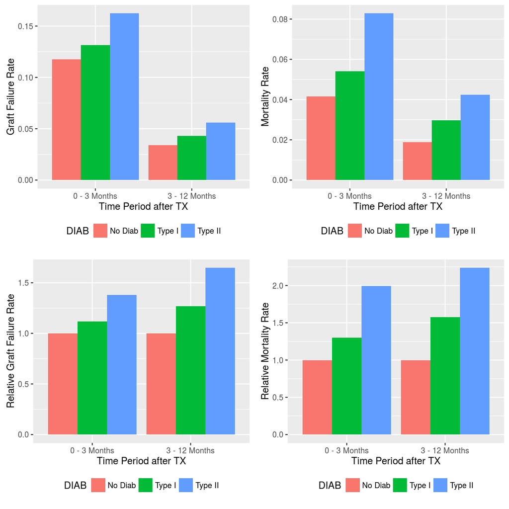

We fit a Cox model with varying effects for diabetes types (Type I, II vs. No). The cutting point for the [time-varying coefficients](http://www.inside-r.org/r-doc/survival/survSplit) are 3 months and 12 months (`tint` is in 0-3 months, 3-12 months or 12 + months).

```
## Call:
## coxph(formula = Surv(tstart, T.GRF, D.GRF) ~ AGEC + GENDER +
##     ETHCAT + DIAB * strata(tint) + PERIP_VASC + BMI + KDPIC +
##     END_CPRA + CIT + HLAMISM + strata(TX_CTR), data = unostd.g)
##
##   n= 264673, number of events= 17373
##
##                                      coef  exp(coef)   se(coef)       z Pr(>|z|)
## AGEC[35,50)                    -0.3604431  0.6973672  0.0278893 -12.924  < 2e-16 ***
## AGEC[50,60)                    -0.2421968  0.7849017  0.0278117  -8.708  < 2e-16 ***
## AGEC[60,75)                     0.0199400  1.0201402  0.0275805   0.723 0.469695
## AGEC[75,100)                    0.3833490  1.4671900  0.0497240   7.710 1.27e-14 ***
## GENDERM                         0.0831849  1.0867427  0.0161943   5.137 2.80e-07 ***
## ETHCATBlack                     0.1508738  1.1628499  0.0195910   7.701 1.34e-14 ***
## ETHCATHispanic                 -0.2348721  0.7906720  0.0285194  -8.236 2.22e-16 ***
## ETHCATAsian                    -0.3883303  0.6781883  0.0424281  -9.153  < 2e-16 ***
## ETHCATOther                     0.0520762  1.0534561  0.0620386   0.839 0.401236
## DIABType I                      0.1114351  1.1178812  0.0823411   1.353 0.175949
## DIABType II                     0.1482402  1.1597914  0.0407907   3.634 0.000279 ***
## PERIP_VASCYes                   0.3487578  1.4173059  0.0323269  10.788  < 2e-16 ***
## PERIP_VASCUnknown/Miss          0.1949858  1.2152937  0.0530843   3.673 0.000240 ***
## BMIUnderweight                  0.1244640  1.1325412  0.0570791   2.181 0.029216 *
## BMIOverweight                  -0.0009037  0.9990967  0.0200807  -0.045 0.964104
## BMIObese                        0.0879905  1.0919777  0.0201296   4.371 1.24e-05 ***
## BMIMissing                      0.0412245  1.0420860  0.1545637   0.267 0.789689
## KDPICMiss                       0.7540286  2.1255458  0.0907231   8.311  < 2e-16 ***
## KDPIC0-10                       0.3116817  1.3657199  0.0461019   6.761 1.37e-11 ***
## KDPIC10-90                      0.5907060  1.8052626  0.0323284  18.272  < 2e-16 ***
## KDPIC90+                        1.0491000  2.8550804  0.0410145  25.579  < 2e-16 ***
## END_CPRA[90,100)                0.2276123  1.2555984  0.0341981   6.656 2.82e-11 ***
## END_CPRAMissing                 0.2059551  1.2286981  0.0420839   4.894 9.89e-07 ***
## CIT[18,30)                      0.0431697  1.0441151  0.0348992   1.237 0.216093
## CIT[6,18)                      -0.0156066  0.9845145  0.0334486  -0.467 0.640797
## CITMissing                      0.0710454  1.0736300  0.0333620   2.130 0.033210 *
## HLAMISM3-4                      0.1386298  1.1486988  0.0236433   5.863 4.54e-09 ***
## HLAMISM5-6                      0.2006555  1.2222036  0.0239153   8.390  < 2e-16 ***
## HLAMISMMissing                  0.6287340  1.8752351  0.0837231   7.510 5.93e-14 ***
## DIABType I:strata(tint)tint=2   0.1474401  1.1588639  0.1181665   1.248 0.212129
## DIABType II:strata(tint)tint=2  0.1612453  1.1749731  0.0575896   2.800 0.005112 **
## DIABType I:strata(tint)tint=3   0.1867161  1.2052850  0.0910052   2.052 0.040198 *
```

[output cut: 29 more lines]

```
## CIT[6,18)                         0.9845     1.0157    0.9220    1.0512
## CITMissing                        1.0736     0.9314    1.0057    1.1462
## HLAMISM3-4                        1.1487     0.8706    1.0967    1.2032
## HLAMISM5-6                        1.2222     0.8182    1.1662    1.2809
## HLAMISMMissing                    1.8752     0.5333    1.5914    2.2096
## DIABType I:strata(tint)tint=2     1.1589     0.8629    0.9193    1.4609
## DIABType II:strata(tint)tint=2    1.1750     0.8511    1.0496    1.3154
## DIABType I:strata(tint)tint=3     1.2053     0.8297    1.0084    1.4406
## DIABType II:strata(tint)tint=3    1.1670     0.8569    1.0687    1.2743
##
## Concordance= 0.634  (se = 0.044 )
## Rsquare= 0.013   (max possible= 0.53 )
## Likelihood ratio test= 3597  on 33 df,   p=0
## Wald test            = 3612  on 33 df,   p=0
## Score (logrank) test = 3767  on 33 df,   p=0
```

```
## Call:
## coxph(formula = Surv(tstart, T.PT, D.PT) ~ AGEC + GENDER + ETHCAT +
##     DIAB * strata(tint) + PERIP_VASC + BMI + KDPIC + END_CPRA +
##     CIT + HLAMISM + strata(TX_CTR), data = unostd.p)
##
##   n= 266251, number of events= 11011
##
##                                     coef exp(coef)  se(coef)       z Pr(>|z|)
## AGEC[35,50)                     0.385347  1.470125  0.054737   7.040 1.92e-12 ***
## AGEC[50,60)                     0.898056  2.454827  0.052715  17.036  < 2e-16 ***
## AGEC[60,75)                     1.370268  3.936404  0.052077  26.312  < 2e-16 ***
## AGEC[75,100)                    1.825425  6.205431  0.067971  26.856  < 2e-16 ***
## GENDERM                         0.152607  1.164867  0.020791   7.340 2.13e-13 ***
## ETHCATBlack                    -0.125658  0.881917  0.025423  -4.943 7.70e-07 ***
## ETHCATHispanic                 -0.369295  0.691221  0.036543 -10.106  < 2e-16 ***
## ETHCATAsian                    -0.553800  0.574761  0.053960 -10.263  < 2e-16 ***
## ETHCATOther                    -0.042925  0.957983  0.077029  -0.557  0.57735
## DIABType I                      0.235146  1.265093  0.129634   1.814  0.06969 .
## DIABType II                     0.313037  1.367572  0.060876   5.142 2.72e-07 ***
## PERIP_VASCYes                   0.460821  1.585376  0.035923  12.828  < 2e-16 ***
## PERIP_VASCUnknown/Miss          0.172465  1.188230  0.065532   2.632  0.00849 **
## BMIUnderweight                  0.328256  1.388545  0.071953   4.562 5.06e-06 ***
## BMIOverweight                  -0.107365  0.898198  0.025207  -4.259 2.05e-05 ***
## BMIObese                       -0.048343  0.952807  0.025487  -1.897  0.05786 .
## BMIMissing                      0.241431  1.273069  0.170967   1.412  0.15791
## KDPICMiss                       0.919087  2.506999  0.110928   8.285  < 2e-16 ***
## KDPIC0-10                       0.531496  1.701476  0.057523   9.240  < 2e-16 ***
## KDPIC10-90                      0.696283  2.006281  0.041833  16.644  < 2e-16 ***
## KDPIC90+                        1.059218  2.884116  0.051420  20.599  < 2e-16 ***
## END_CPRA[90,100)                0.254128  1.289336  0.044865   5.664 1.48e-08 ***
## END_CPRAMissing                 0.283138  1.327289  0.053871   5.256 1.47e-07 ***
## CIT[18,30)                      0.002634  1.002637  0.044503   0.059  0.95280
## CIT[6,18)                      -0.016665  0.983474  0.042731  -0.390  0.69655
## CITMissing                      0.019860  1.020058  0.043242   0.459  0.64604
## HLAMISM3-4                      0.092780  1.097220  0.029379   3.158  0.00159 **
## HLAMISM5-6                      0.145716  1.156867  0.029696   4.907 9.25e-07 ***
## HLAMISMMissing                  0.771468  2.162938  0.096691   7.979 1.44e-15 ***
## DIABType I:strata(tint)tint=2   0.176573  1.193122  0.165715   1.066  0.28664
## DIABType II:strata(tint)tint=2  0.112639  1.119228  0.078645   1.432  0.15207
## DIABType I:strata(tint)tint=3   0.349245  1.417996  0.136916   2.551  0.01075 *
```

[output cut: 29 more lines]

```
## CIT[6,18)                         0.9835     1.0168    0.9045    1.0694
## CITMissing                        1.0201     0.9803    0.9372    1.1103
## HLAMISM3-4                        1.0972     0.9114    1.0358    1.1623
## HLAMISM5-6                        1.1569     0.8644    1.0915    1.2262
## HLAMISMMissing                    2.1629     0.4623    1.7895    2.6143
## DIABType I:strata(tint)tint=2     1.1931     0.8381    0.8622    1.6510
## DIABType II:strata(tint)tint=2    1.1192     0.8935    0.9593    1.3058
## DIABType I:strata(tint)tint=3     1.4180     0.7052    1.0843    1.8545
## DIABType II:strata(tint)tint=3    1.1847     0.8441    1.0434    1.3451
##
## Concordance= 0.706  (se = 0.056 )
## Rsquare= 0.021   (max possible= 0.373 )
## Likelihood ratio test= 5643  on 33 df,   p=0
## Wald test            = 5163  on 33 df,   p=0
## Score (logrank) test = 5837  on 33 df,   p=0
```

TOC

## Interaction between Dialysis Time and Diabetes

- both dialysis dates are non-missing and equal; use either one;
- both dialysis dates are non-missing and unequal, but one is after `TX_DATE`; use the one precedes `TX_DATE`;
- both dialysis dates are non-missing and unequal, and both precede `TX_DATE`; use `DIALYSIS_DATE`;
- only one of `DIAL_DATE` and `DIALYSIS_DATE` is missing; use the non-missing dialysis date in the calculation;
- `Preemptive`: both `DIAL_DATE` and `DIALYSIS_DATE` are missing and `DIAL_TRR == "N"`;
- `Miss`: both `DIAL_DATE` and `DIALYSIS_DATE` are missing and `DIAL_TRR != "N"`.

```
##       TDIALC        LD        CD
## 1       Miss 0.3957399 0.6042601
## 2 Preemptive 0.6512842 0.3487158
## 3        0-2 0.5445587 0.4554413
## 4         2+ 0.1495152 0.8504848
```

We inspect the one-year graft failure rate and the mortality rate for different combination of dialysis time and diabetes status.

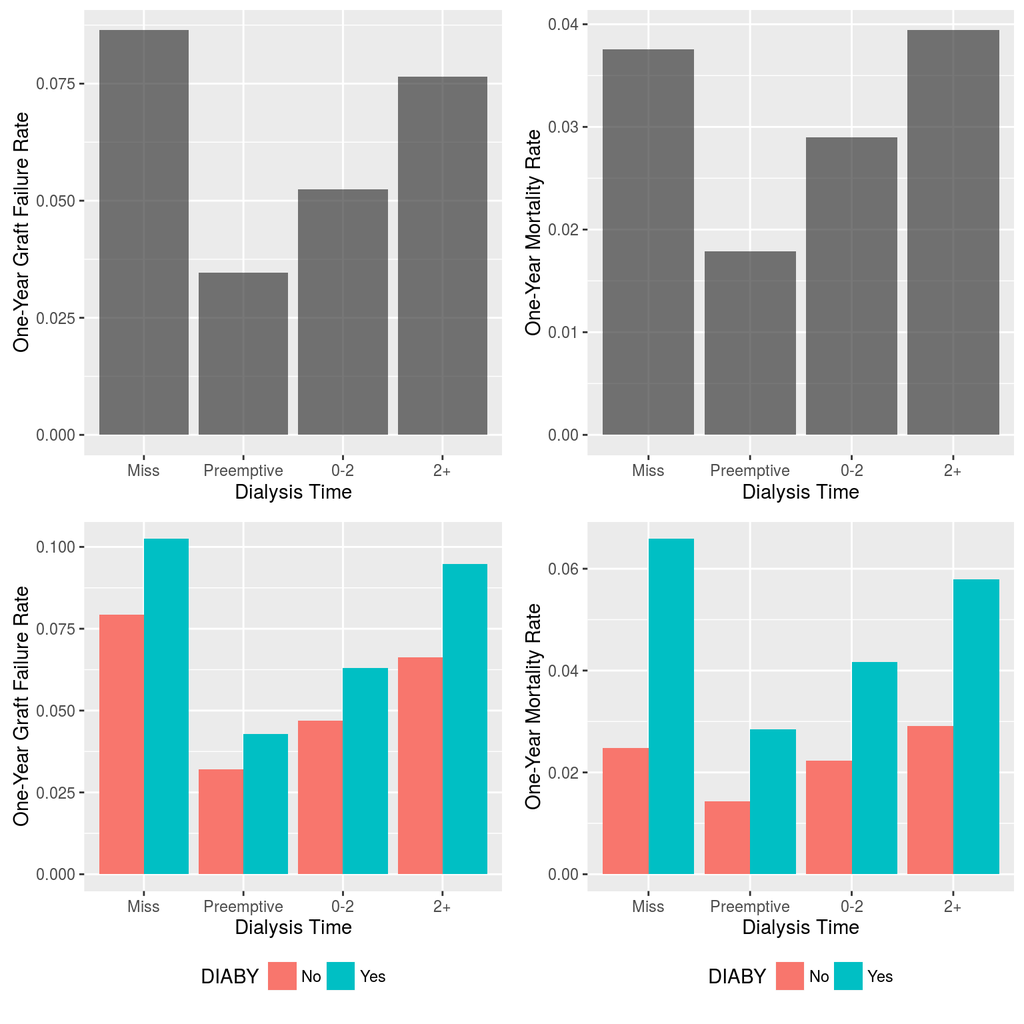

We fit stratified Cox models with everything including the interaction between diabetes status (Yes or No (the reference)) and dialysis time (TDIALC, `Preemptive` as the reference). Preemptive kidney transplants on average have better suvival outcomes, but the benificial effects is smaller in meganitude for diabetic patients (indicated by negative interaction coefficient estimates).

```
## Call:
## coxph(formula = Surv(T.GRF, D.GRF) ~ AGEC + GENDER + ETHCAT +
##     DIABY * TDIALC + PERIP_VASC + BMI + KDPIC + END_CPRA + CIT +
##     HLAMISM + strata(TX_CTR), data = unos1)
##
##   n= 94827, number of events= 18022
##
##                             coef exp(coef)  se(coef)       z Pr(>|z|)
## AGEC[35,50)            -0.348198  0.705959  0.027696 -12.572  < 2e-16 ***
## AGEC[50,60)            -0.217765  0.804315  0.027533  -7.909 2.55e-15 ***
## AGEC[60,75)             0.053794  1.055268  0.027154   1.981  0.04758 *
## AGEC[75,100)            0.398368  1.489392  0.048997   8.131 4.44e-16 ***
## GENDERM                 0.066009  1.068237  0.015887   4.155 3.25e-05 ***
## ETHCATBlack             0.082419  1.085911  0.019454   4.237 2.27e-05 ***
## ETHCATHispanic         -0.290114  0.748178  0.027937 -10.385  < 2e-16 ***
## ETHCATAsian            -0.428411  0.651543  0.041470 -10.331  < 2e-16 ***
## ETHCATOther            -0.029239  0.971185  0.060835  -0.481  0.63079
## DIABYYes                0.338839  1.403317  0.048982   6.918 4.59e-12 ***
## TDIALCMiss              0.425377  1.530166  0.103961   4.092 4.28e-05 ***
## TDIALC0-2               0.424370  1.528627  0.034472  12.311  < 2e-16 ***
## TDIALC2+                0.560330  1.751250  0.033203  16.876  < 2e-16 ***
## PERIP_VASCYes           0.312719  1.367137  0.031813   9.830  < 2e-16 ***
## PERIP_VASCUnknown/Miss  0.149177  1.160878  0.050413   2.959  0.00309 **
## BMIUnderweight          0.121620  1.129324  0.056413   2.156  0.03109 *
## BMIOverweight          -0.006007  0.994011  0.019736  -0.304  0.76085
## BMIObese                0.077208  1.080266  0.019679   3.923 8.73e-05 ***
## BMIMissing             -0.001285  0.998716  0.150583  -0.009  0.99319
## KDPICMiss               0.616701  1.852806  0.087403   7.056 1.72e-12 ***
## KDPIC0-10               0.195521  1.215944  0.045759   4.273 1.93e-05 ***
## KDPIC10-90              0.460427  1.584751  0.032642  14.105  < 2e-16 ***
## KDPIC90+                0.915017  2.496818  0.040788  22.433  < 2e-16 ***
## END_CPRA[90,100)        0.185464  1.203777  0.033742   5.497 3.87e-08 ***
## END_CPRAMissing         0.225587  1.253058  0.041579   5.426 5.78e-08 ***
## CIT[18,30)              0.046081  1.047159  0.034300   1.343  0.17912
## CIT[6,18)              -0.013589  0.986503  0.032900  -0.413  0.67958
## CITMissing              0.080996  1.084367  0.032872   2.464  0.01374 *
## HLAMISM3-4              0.116289  1.123320  0.023366   4.977 6.46e-07 ***
## HLAMISM5-6              0.183928  1.201930  0.023606   7.792 6.66e-15 ***
## HLAMISMMissing          0.722745  2.060080  0.082183   8.794  < 2e-16 ***
## DIABYYes:TDIALCMiss     0.158880  1.172197  0.161839   0.982  0.32624
```

[output cut: 31 more lines]

```
## CIT[18,30)                1.0472     0.9550    0.9791    1.1200
## CIT[6,18)                 0.9865     1.0137    0.9249    1.0522
## CITMissing                1.0844     0.9222    1.0167    1.1565
## HLAMISM3-4                1.1233     0.8902    1.0730    1.1760
## HLAMISM5-6                1.2019     0.8320    1.1476    1.2588
## HLAMISMMissing            2.0601     0.4854    1.7536    2.4201
## DIABYYes:TDIALCMiss       1.1722     0.8531    0.8536    1.6098
## DIABYYes:TDIALC0-2        0.8833     1.1321    0.7901    0.9874
## DIABYYes:TDIALC2+         0.9291     1.0763    0.8385    1.0296
##
## Concordance= 0.64  (se = 0.025 )
## Rsquare= 0.043   (max possible= 0.889 )
## Likelihood ratio test= 4165  on 34 df,   p=0
## Wald test            = 4058  on 34 df,   p=0
## Score (logrank) test = 4278  on 34 df,   p=0
```

```
## Call:
## coxph(formula = Surv(T.PT, D.PT) ~ AGEC + GENDER + ETHCAT + DIABY *
##     TDIALC + PERIP_VASC + BMI + KDPIC + END_CPRA + CIT + HLAMISM +
##     strata(TX_CTR), data = unos1)
##
##   n= 94827, number of events= 11568
##
##                             coef exp(coef)  se(coef)       z Pr(>|z|)
## AGEC[35,50)             0.392673  1.480933  0.053991   7.273 3.52e-13 ***
## AGEC[50,60)             0.904199  2.469953  0.051995  17.390  < 2e-16 ***
## AGEC[60,75)             1.378281  3.968076  0.051269  26.883  < 2e-16 ***
## AGEC[75,100)            1.811636  6.120452  0.066923  27.070  < 2e-16 ***
## GENDERM                 0.128356  1.136958  0.020259   6.336 2.36e-10 ***
## ETHCATBlack            -0.204225  0.815279  0.025008  -8.166 3.33e-16 ***
## ETHCATHispanic         -0.437244  0.645814  0.035403 -12.350  < 2e-16 ***
## ETHCATAsian            -0.603556  0.546863  0.052330 -11.534  < 2e-16 ***
## ETHCATOther            -0.170602  0.843157  0.075576  -2.257  0.02399 *
## DIABYYes                0.537224  1.711250  0.059182   9.078  < 2e-16 ***
## TDIALCMiss              0.370986  1.449163  0.142030   2.612  0.00900 **
## TDIALC0-2               0.439950  1.552629  0.046486   9.464  < 2e-16 ***
## TDIALC2+                0.620749  1.860321  0.044013  14.104  < 2e-16 ***
## PERIP_VASCYes           0.418262  1.519318  0.035261  11.862  < 2e-16 ***
## PERIP_VASCUnknown/Miss  0.109050  1.115218  0.061630   1.769  0.07682 .
## BMIUnderweight          0.316789  1.372713  0.070891   4.469 7.87e-06 ***
## BMIOverweight          -0.113038  0.893117  0.024604  -4.594 4.34e-06 ***
## BMIObese               -0.067001  0.935194  0.024739  -2.708  0.00676 **
## BMIMissing              0.176567  1.193114  0.167391   1.055  0.29151
## KDPICMiss               0.709506  2.032988  0.107288   6.613 3.76e-11 ***
## KDPIC0-10               0.394925  1.484273  0.056684   6.967 3.23e-12 ***
## KDPIC10-90              0.543854  1.722633  0.041820  13.004  < 2e-16 ***
## KDPIC90+                0.899272  2.457813  0.050813  17.698  < 2e-16 ***
## END_CPRA[90,100)        0.204212  1.226558  0.044041   4.637 3.54e-06 ***
## END_CPRAMissing         0.294851  1.342926  0.053094   5.553 2.80e-08 ***
## CIT[18,30)              0.001175  1.001176  0.043426   0.027  0.97842
## CIT[6,18)              -0.017034  0.983110  0.041712  -0.408  0.68300
## CITMissing              0.035120  1.035744  0.042328   0.830  0.40670
## HLAMISM3-4              0.068740  1.071157  0.028903   2.378  0.01739 *
## HLAMISM5-6              0.128115  1.136684  0.029181   4.390 1.13e-05 ***
## HLAMISMMissing          0.906411  2.475422  0.094406   9.601  < 2e-16 ***
## DIABYYes:TDIALCMiss     0.280742  1.324111  0.198443   1.415  0.15715
```

[output cut: 31 more lines]

```
## CIT[18,30)                1.0012     0.9988    0.9195    1.0901
## CIT[6,18)                 0.9831     1.0172    0.9059    1.0669
## CITMissing                1.0357     0.9655    0.9533    1.1253
## HLAMISM3-4                1.0712     0.9336    1.0122    1.1336
## HLAMISM5-6                1.1367     0.8798    1.0735    1.2036
## HLAMISMMissing            2.4754     0.4040    2.0573    2.9786
## DIABYYes:TDIALCMiss       1.3241     0.7552    0.8974    1.9536
## DIABYYes:TDIALC0-2        0.8699     1.1495    0.7593    0.9967
## DIABYYes:TDIALC2+         0.9410     1.0627    0.8308    1.0657
##
## Concordance= 0.709  (se = 0.032 )
## Rsquare= 0.064   (max possible= 0.749 )
## Likelihood ratio test= 6241  on 34 df,   p=0
## Wald test            = 5657  on 34 df,   p=0
## Score (logrank) test = 6451  on 34 df,   p=0
```

TOC